# Lab 05 - Halloween Candies & Data Viz Improvement

Thomas Ansell

2026-10-30

### Load packages

```r
library(tidyverse)
library(ggplot2)
```

# Questioning data visualisations

## Image 1

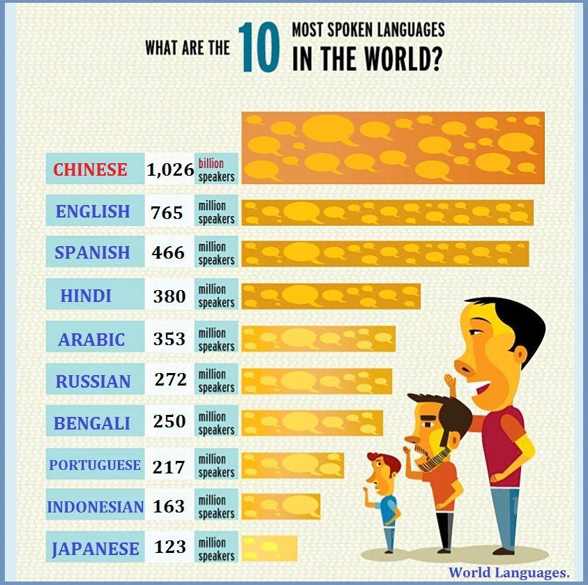

## Image 2

[figure not shown]

## Image 3

[figure not shown]

## Image 4

[figure not shown]

# Data Visualization for Halloween

Ensure that you have the following two lines of code at the top of `lab-05.Rmd` to make the commands available to you.

```r
library(tidyverse)
library(ggplot2)

# Install that package first
# install.packages("fivethirtyeight")
library(fivethirtyeight)
```

```r
candy_df <- candy_rankings
glimpse(candy_df)
```

```
## Rows: 85
## Columns: 13
## $ competitorname   <chr> "100 Grand", "3 Musketeers", "One dime", "One quarter…
## $ chocolate        <lgl> TRUE, TRUE, FALSE, FALSE, FALSE, TRUE, TRUE, FALSE, F…
## $ fruity           <lgl> FALSE, FALSE, FALSE, FALSE, TRUE, FALSE, FALSE, FALSE…
## $ caramel          <lgl> TRUE, FALSE, FALSE, FALSE, FALSE, FALSE, TRUE, FALSE,…
## $ peanutyalmondy   <lgl> FALSE, FALSE, FALSE, FALSE, FALSE, TRUE, TRUE, TRUE, …
## $ nougat           <lgl> FALSE, TRUE, FALSE, FALSE, FALSE, FALSE, TRUE, FALSE,…
## $ crispedricewafer <lgl> TRUE, FALSE, FALSE, FALSE, FALSE, FALSE, FALSE, FALSE…
## $ hard             <lgl> FALSE, FALSE, FALSE, FALSE, FALSE, FALSE, FALSE, FALS…
## $ bar              <lgl> TRUE, TRUE, FALSE, FALSE, FALSE, TRUE, TRUE, FALSE, F…
## $ pluribus         <lgl> FALSE, FALSE, FALSE, FALSE, FALSE, FALSE, FALSE, TRUE…
## $ sugarpercent     <dbl> 0.732, 0.604, 0.011, 0.011, 0.906, 0.465, 0.604, 0.31…
## $ pricepercent     <dbl> 0.860, 0.511, 0.116, 0.511, 0.511, 0.767, 0.767, 0.51…
## $ winpercent       <dbl> 66.97173, 67.60294, 32.26109, 46.11650, 52.34146, 50.…
```

## Exercise 1

How many observations and variables are in this dataset? Did you identify the type of variables, remember that this detail is crucial to create which kind of data visualization in general.

# Data viz - One variable at a time

Just to use the logical variables as categories, run the following code chunk first!

```r
candy_df <- candy_df %>%
  mutate(across(where(is.logical), as_factor))
```

## Exercise 2

Complete the following code to get the data viz to represent “how many candies contain caramel via bar plot”. Fill in the blanks, remove the # symbol in front of your code and the execute the code chunk via green play button.

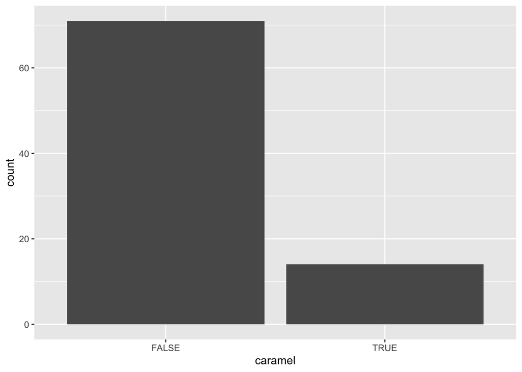

```r
ggplot(candy_rankings, aes(x = caramel)) +
  geom_bar()
```

## Exercise 3

Now look at a numerical variable, such as `winpercent`. Create an histogram for this variable using ggplot2 functions below. Include informative x and y labels and a title, as a good practice.

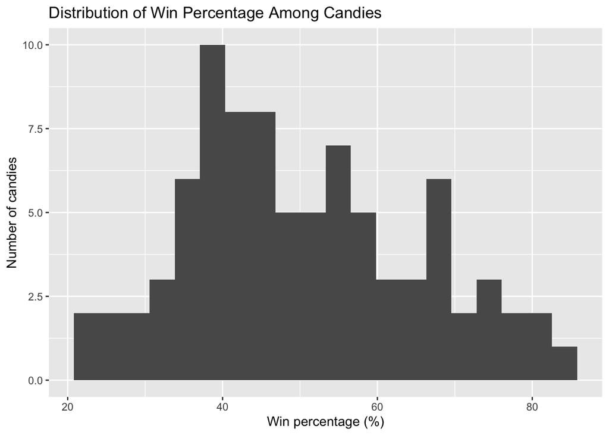

```r
ggplot(candy_rankings, aes(x = winpercent)) +
  geom_histogram(bins = 20) +
  labs(
    title = "Distribution of Win Percentage Among Candies",
    x = "Win percentage (%)",
    y = "Number of candies"
  )
```

# Data viz - more than one variable

## Exercise 4

How about using the both variables; chocolate vs winpercent? Run the following incomplete code snippet to get a faceted visualization.

Fill in the blanks, remove the # symbol in front of your code and the execute the code chunk via green play button.

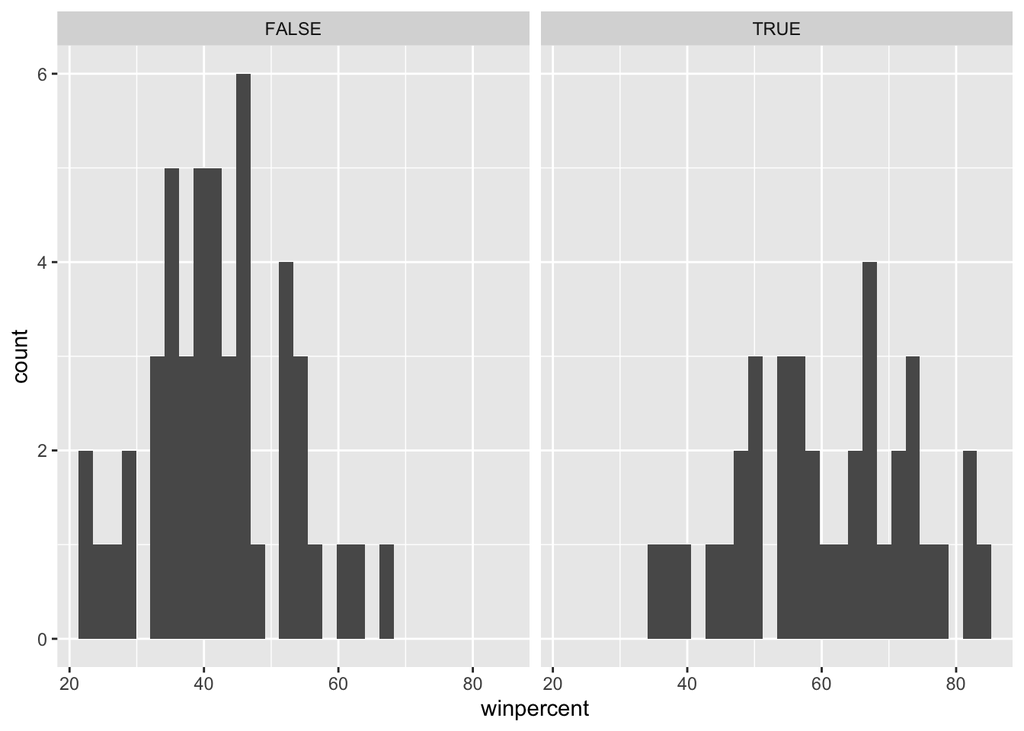

```r
ggplot(candy_df, aes(x = winpercent)) +
  geom_histogram() +
  facet_wrap(~ chocolate)
```

- Consider adding the `fill = caramel` within the aes() vs. geom_histogram(), what do you get?

## Exercise 5

Create a visualization that examines the relationship between a candy’s win percentage and whether it contains chocolate. Include x and y labels and a title. Describe any relationship you see.

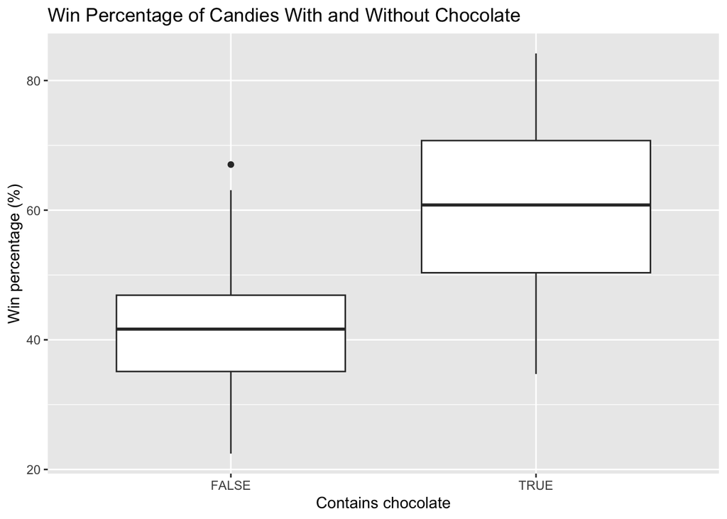

```r
ggplot(candy_rankings, aes(x = chocolate, y = winpercent)) +
  geom_boxplot() +
  labs(
    title = "Win Percentage of Candies With and Without Chocolate",
    x = "Contains chocolate",
    y = "Win percentage (%)"
  )
```

- Consider the similar pair by replacing chocolate with caramel, fruity and compare their results.
- Also include summary statistics details for this discussion by using the calculation below:

```r
candy_rankings %>%
  group_by(chocolate) %>%
  summarise(
    n = n(),
    mean_win = mean(winpercent),
    median_win = median(winpercent)
  )
```

```
## # A tibble: 2 × 4
##   chocolate     n mean_win median_win
##   <lgl>     <int>    <dbl>      <dbl>
## 1 FALSE        48     42.1       41.6
## 2 TRUE         37     60.9       60.8
```

## Exercise 6

Do more expensive candies win more often? Make a scatterplot of pricepercent (x) against winpercent (y). Describe their relationship.

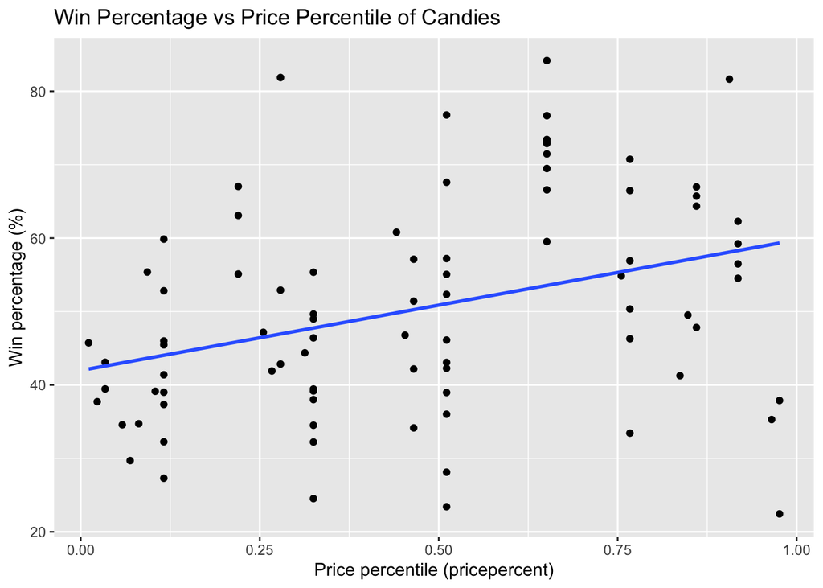

```r
ggplot(candy_rankings, aes(x = pricepercent, y = winpercent)) +
  geom_point() +
  geom_smooth(method = "lm", se = FALSE) +
  labs(
    title = "Win Percentage vs Price Percentile of Candies",
    x = "Price percentile (pricepercent)",
    y = "Win percentage (%)"
  )
```

- Add `color = chocolate` to add a third variable to the created visualization
- How to facet this by using another categorical variable such as `bar`?

## Exercise 7

Are chocolate candies more likely to be candy bars? Make a filled bar plot with chocolate on the x-axis and fill = bar. Describe what you see.

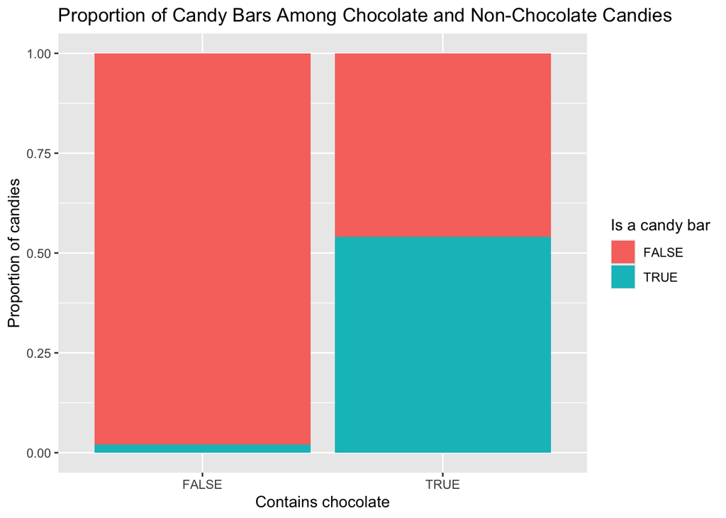

```r
ggplot(candy_rankings, aes(x = chocolate, fill = bar)) +
  geom_bar(position = "fill") +
  labs(
    title = "Proportion of Candy Bars Among Chocolate and Non-Chocolate Candies",
    x = "Contains chocolate",
    y = "Proportion of candies",
    fill = "Is a candy bar"
  )
```